# Linear Model Selection and Regularization

Emily Blue

`2-26-24`

### Overview:

This R Markdown file includes my completion of **ISLR chapter 6**, exercises 9 and 11 .

#### Exercise 9: Predict College Applications

- **Objective**: Predict number of college applications received with five regression approaches.
- **Steps**:
  - Split data into training set and test set.
  - Fit a **Linear Model** using least squares.
  - Perform **Best Subset Selection** and, **Forward and Backward Selection**.
  - Fit a **Ridge Regression** model with λ chosen by cross-validation.
  - Fit a **Lasso model** with λ chosen by cross validation.
  - Fit a **Principal Component Regression** model with M chosen by cross validation.
  - Fit a **Partial Least Squares** model with M chosen by cross validation
  - Comment on the five approaches.

#### Exercise 11: Predict per Capita Crime Rate

- **Objective**: Predict per capita crime rate in the Boston data set.
- **Steps**:
  - Performing **Ridge Regression, Lasso, PCR, PLS,** and proposing best model.

```r
library(tidyverse)
library(openintro)
library(ISLR2)
library(dplyr)
library(glmnet)
library(leaps)
library(pls)
data("College")
```

## Predict College Applications

### a) Split the data set into a training set and a test set.

```r
x <- model.matrix(Apps ~ ., College)[, -1]
y <- College$Apps

set.seed(777)

train <- sample(c(TRUE, FALSE), nrow(College),
replace = TRUE)
test <- (!train)

# Using this
set.seed(777)
train <- sample(1:nrow(x), nrow(x) / 2)
test <- (-train)
y.test <- y[test]
```

### b) Linear model

#### Fit a linear model using least squares on the training set and report the test error obtained.

```r
lm.fit <- lm(Apps ~., data = College, subset = train)
lm.pred <- predict(lm.fit, College[test,])
lm.error <- mean((lm.pred - y.test)^2)
lm.error
```

```
## [1] 1503171
```

Test MSE is 1503171

#### Best Subset Selection

```r
regfit.full <- regsubsets(Apps ~ ., data = College)
summary(regfit.full)
```

```
## Subset selection object
## Call: regsubsets.formula(Apps ~ ., data = College)
## 17 Variables  (and intercept)
##             Forced in Forced out
## PrivateYes      FALSE      FALSE
## Accept          FALSE      FALSE
## Enroll          FALSE      FALSE
## Top10perc       FALSE      FALSE
## Top25perc       FALSE      FALSE
## F.Undergrad     FALSE      FALSE
## P.Undergrad     FALSE      FALSE
## Outstate        FALSE      FALSE
## Room.Board      FALSE      FALSE
## Books           FALSE      FALSE
## Personal        FALSE      FALSE
## PhD             FALSE      FALSE
## Terminal        FALSE      FALSE
## S.F.Ratio       FALSE      FALSE
## perc.alumni     FALSE      FALSE
## Expend          FALSE      FALSE
## Grad.Rate       FALSE      FALSE
## 1 subsets of each size up to 8
## Selection Algorithm: exhaustive
##          PrivateYes Accept Enroll Top10perc Top25perc F.Undergrad P.Undergrad
## 1  ( 1 ) " "        "*"    " "    " "       " "       " "         " "
## 2  ( 1 ) " "        "*"    " "    "*"       " "       " "         " "
## 3  ( 1 ) " "        "*"    " "    "*"       " "       " "         " "
## 4  ( 1 ) " "        "*"    " "    "*"       " "       " "         " "
## 5  ( 1 ) " "        "*"    "*"    "*"       " "       " "         " "
## 6  ( 1 ) " "        "*"    "*"    "*"       " "       " "         " "
## 7  ( 1 ) " "        "*"    "*"    "*"       "*"       " "         " "
## 8  ( 1 ) "*"        "*"    "*"    "*"       " "       " "         " "
##          Outstate Room.Board Books Personal PhD Terminal S.F.Ratio perc.alumni
## 1  ( 1 ) " "      " "        " "   " "      " " " "      " "       " "
## 2  ( 1 ) " "      " "        " "   " "      " " " "      " "       " "
## 3  ( 1 ) " "      " "        " "   " "      " " " "      " "       " "
## 4  ( 1 ) "*"      " "        " "   " "      " " " "      " "       " "
## 5  ( 1 ) "*"      " "        " "   " "      " " " "      " "       " "
## 6  ( 1 ) "*"      "*"        " "   " "      " " " "      " "       " "
## 7  ( 1 ) "*"      "*"        " "   " "      " " " "      " "       " "
## 8  ( 1 ) "*"      "*"        " "   " "      "*" " "      " "       " "
##          Expend Grad.Rate
## 1  ( 1 ) " "    " "
## 2  ( 1 ) " "    " "
## 3  ( 1 ) "*"    " "
## 4  ( 1 ) "*"    " "
## 5  ( 1 ) "*"    " "
## 6  ( 1 ) "*"    " "
## 7  ( 1 ) "*"    " "
## 8  ( 1 ) "*"    " "
```

```r
regfit.full <- regsubsets(Apps ~ ., data = College, nvmax = 17)
reg.summary <- summary(regfit.full)
names(reg.summary)
```

```
## [1] "which"  "rsq"    "rss"    "adjr2"  "cp"     "bic"    "outmat" "obj"
```

```r
reg.summary$rsq
```

```
##  [1] 0.8900990 0.9157839 0.9183356 0.9212640 0.9237599 0.9247464 0.9257649
##  [8] 0.9268725 0.9276780 0.9283103 0.9288011 0.9289945 0.9291223 0.9291632
## [15] 0.9291878 0.9291885 0.9291887
```

```r
par(mfrow = c(2, 2))

plot(reg.summary$rss, xlab = "Number of Variables", ylab = "RSS", type = "l")
plot(reg.summary$adjr2, xlab = "Number of Variables", ylab = "Adjusted RSq", type = "l")

which.max(reg.summary$adjr2)
```

```
## [1] 13
```

```r
# 13

plot(reg.summary$adjr2, xlab = "Number of Variables", ylab = "Adjusted RSq", type = "l")
points(13, reg.summary$adjr2[13], col = "red", cex = 2, pch = 20)


which.min(reg.summary$cp)
```

```
## [1] 12
```

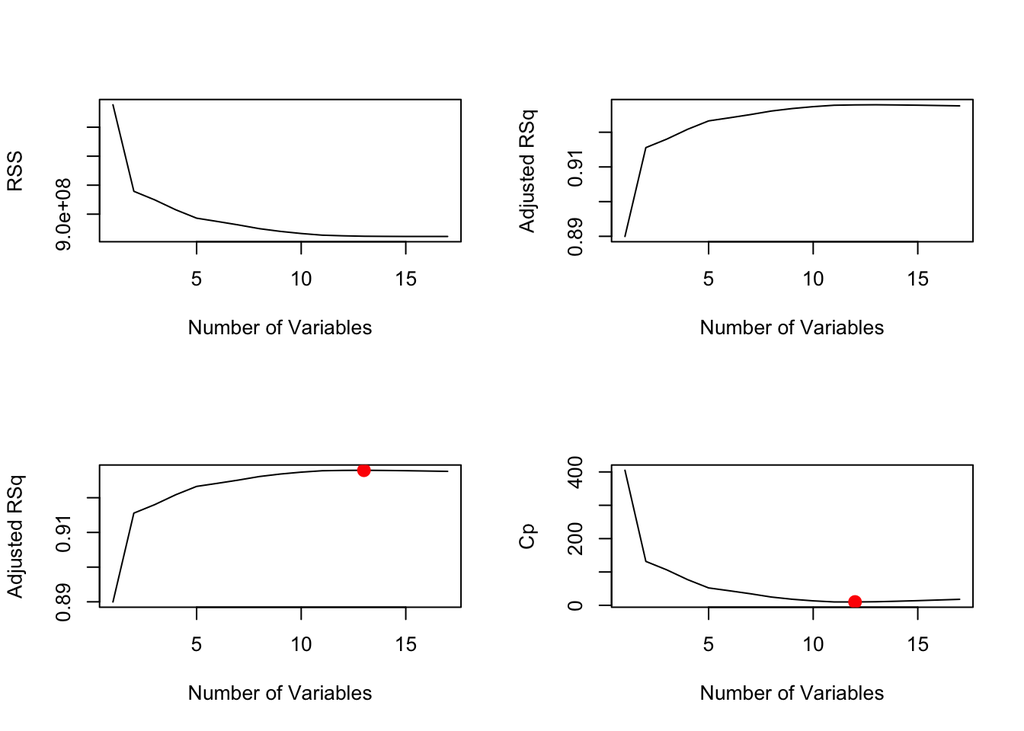

```r
#12

plot(reg.summary$cp, xlab = "Number of Variables", ylab = "Cp", type = "l")
points(12, reg.summary$cp[12], col = "red", cex = 2,pch = 20)
```

```r
which.min(reg.summary$bic)
```

```
## [1] 10
```

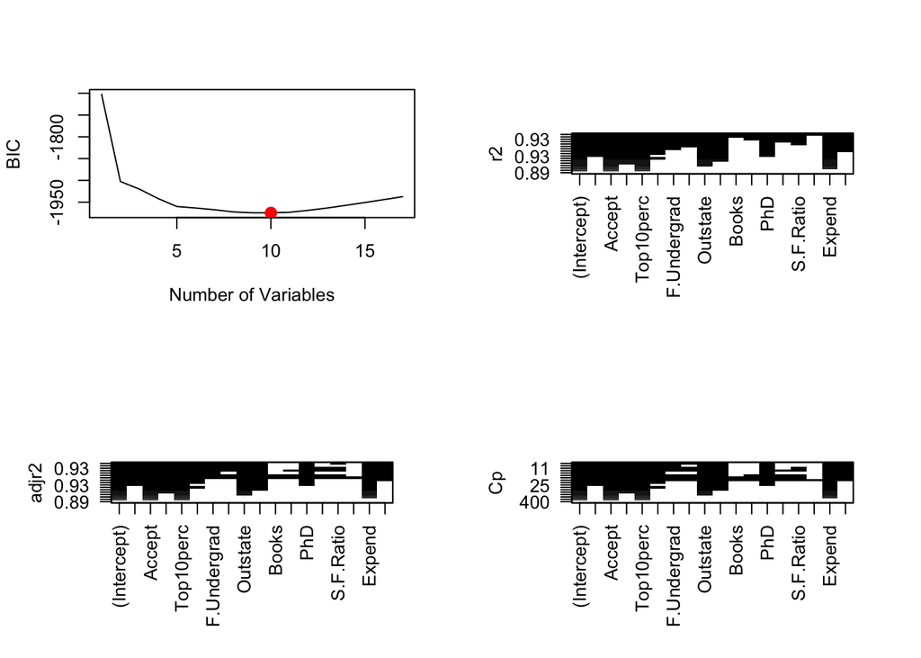

```r
#10

plot(reg.summary$bic, xlab = "Number of Variables", ylab = "BIC", type = "l")
points(10, reg.summary$bic[10], col = "red", cex = 2, pch = 20)


plot(regfit.full, scale = "r2")
plot(regfit.full, scale = "adjr2")
plot(regfit.full, scale = "Cp")
```

```
##   (Intercept)        Accept     Top10perc        Expend
## -1.106281e+03  1.440313e+00  2.606376e+01  4.988825e-02
```

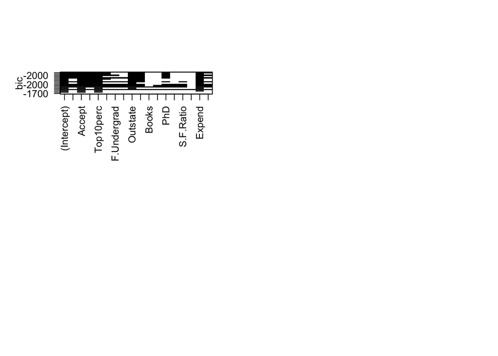

```r
plot(regfit.full, scale = "bic")

coef(regfit.full, 3)
```

#### Forward and Backward Selection

```r
regfit.fwd <- regsubsets(Apps ~ ., data = College, nvmax = 17, method = "forward")
summary(regfit.fwd)
```

```
## Subset selection object
## Call: regsubsets.formula(Apps ~ ., data = College, nvmax = 17, method = "forward")
## 17 Variables  (and intercept)
##             Forced in Forced out
## PrivateYes      FALSE      FALSE
## Accept          FALSE      FALSE
## Enroll          FALSE      FALSE
## Top10perc       FALSE      FALSE
## Top25perc       FALSE      FALSE
## F.Undergrad     FALSE      FALSE
## P.Undergrad     FALSE      FALSE
## Outstate        FALSE      FALSE
## Room.Board      FALSE      FALSE
## Books           FALSE      FALSE
## Personal        FALSE      FALSE
## PhD             FALSE      FALSE
## Terminal        FALSE      FALSE
## S.F.Ratio       FALSE      FALSE
## perc.alumni     FALSE      FALSE
## Expend          FALSE      FALSE
## Grad.Rate       FALSE      FALSE
## 1 subsets of each size up to 17
## Selection Algorithm: forward
##           PrivateYes Accept Enroll Top10perc Top25perc F.Undergrad P.Undergrad
## 1  ( 1 )  " "        "*"    " "    " "       " "       " "         " "
## 2  ( 1 )  " "        "*"    " "    "*"       " "       " "         " "
## 3  ( 1 )  " "        "*"    " "    "*"       " "       " "         " "
## 4  ( 1 )  " "        "*"    " "    "*"       " "       " "         " "
## 5  ( 1 )  " "        "*"    "*"    "*"       " "       " "         " "
## 6  ( 1 )  " "        "*"    "*"    "*"       " "       " "         " "
## 7  ( 1 )  " "        "*"    "*"    "*"       "*"       " "         " "
## 8  ( 1 )  "*"        "*"    "*"    "*"       "*"       " "         " "
## 9  ( 1 )  "*"        "*"    "*"    "*"       "*"       " "         " "
## 10  ( 1 ) "*"        "*"    "*"    "*"       "*"       " "         " "
## 11  ( 1 ) "*"        "*"    "*"    "*"       "*"       "*"         " "
## 12  ( 1 ) "*"        "*"    "*"    "*"       "*"       "*"         "*"
## 13  ( 1 ) "*"        "*"    "*"    "*"       "*"       "*"         "*"
## 14  ( 1 ) "*"        "*"    "*"    "*"       "*"       "*"         "*"
## 15  ( 1 ) "*"        "*"    "*"    "*"       "*"       "*"         "*"
## 16  ( 1 ) "*"        "*"    "*"    "*"       "*"       "*"         "*"
```

[output cut: 22 more lines]

```
## 3  ( 1 )  "*"    " "
## 4  ( 1 )  "*"    " "
## 5  ( 1 )  "*"    " "
## 6  ( 1 )  "*"    " "
## 7  ( 1 )  "*"    " "
## 8  ( 1 )  "*"    " "
## 9  ( 1 )  "*"    " "
## 10  ( 1 ) "*"    "*"
## 11  ( 1 ) "*"    "*"
## 12  ( 1 ) "*"    "*"
## 13  ( 1 ) "*"    "*"
## 14  ( 1 ) "*"    "*"
## 15  ( 1 ) "*"    "*"
## 16  ( 1 ) "*"    "*"
## 17  ( 1 ) "*"    "*"
```

```r
regfit.bwd <- regsubsets(Apps ~ ., data = College, nvmax = 17, method = "backward")
summary(regfit.bwd)
```

```
## Subset selection object
## Call: regsubsets.formula(Apps ~ ., data = College, nvmax = 17, method = "backward")
## 17 Variables  (and intercept)
##             Forced in Forced out
## PrivateYes      FALSE      FALSE
## Accept          FALSE      FALSE
## Enroll          FALSE      FALSE
## Top10perc       FALSE      FALSE
## Top25perc       FALSE      FALSE
## F.Undergrad     FALSE      FALSE
## P.Undergrad     FALSE      FALSE
## Outstate        FALSE      FALSE
## Room.Board      FALSE      FALSE
## Books           FALSE      FALSE
## Personal        FALSE      FALSE
## PhD             FALSE      FALSE
## Terminal        FALSE      FALSE
## S.F.Ratio       FALSE      FALSE
## perc.alumni     FALSE      FALSE
## Expend          FALSE      FALSE
## Grad.Rate       FALSE      FALSE
## 1 subsets of each size up to 17
## Selection Algorithm: backward
##           PrivateYes Accept Enroll Top10perc Top25perc F.Undergrad P.Undergrad
## 1  ( 1 )  " "        "*"    " "    " "       " "       " "         " "
## 2  ( 1 )  " "        "*"    " "    "*"       " "       " "         " "
## 3  ( 1 )  " "        "*"    " "    "*"       " "       " "         " "
## 4  ( 1 )  " "        "*"    " "    "*"       " "       " "         " "
## 5  ( 1 )  " "        "*"    "*"    "*"       " "       " "         " "
## 6  ( 1 )  " "        "*"    "*"    "*"       " "       " "         " "
## 7  ( 1 )  "*"        "*"    "*"    "*"       " "       " "         " "
## 8  ( 1 )  "*"        "*"    "*"    "*"       " "       " "         " "
## 9  ( 1 )  "*"        "*"    "*"    "*"       "*"       " "         " "
## 10  ( 1 ) "*"        "*"    "*"    "*"       "*"       " "         " "
## 11  ( 1 ) "*"        "*"    "*"    "*"       "*"       "*"         " "
## 12  ( 1 ) "*"        "*"    "*"    "*"       "*"       "*"         "*"
## 13  ( 1 ) "*"        "*"    "*"    "*"       "*"       "*"         "*"
## 14  ( 1 ) "*"        "*"    "*"    "*"       "*"       "*"         "*"
## 15  ( 1 ) "*"        "*"    "*"    "*"       "*"       "*"         "*"
## 16  ( 1 ) "*"        "*"    "*"    "*"       "*"       "*"         "*"
```

[output cut: 22 more lines]

```
## 3  ( 1 )  "*"    " "
## 4  ( 1 )  "*"    " "
## 5  ( 1 )  "*"    " "
## 6  ( 1 )  "*"    " "
## 7  ( 1 )  "*"    " "
## 8  ( 1 )  "*"    " "
## 9  ( 1 )  "*"    " "
## 10  ( 1 ) "*"    "*"
## 11  ( 1 ) "*"    "*"
## 12  ( 1 ) "*"    "*"
## 13  ( 1 ) "*"    "*"
## 14  ( 1 ) "*"    "*"
## 15  ( 1 ) "*"    "*"
## 16  ( 1 ) "*"    "*"
## 17  ( 1 ) "*"    "*"
```

When using either forward or backward stepwise selection, the best one-variable model contains only Accept, and the best two variable model would also include Top10perc.

#### Choosing Among Models

```r
set.seed(777)

train <- sample(c(TRUE, FALSE), nrow(Hitters),replace = TRUE)
test <- (!train)

regfit.best <- regsubsets(Apps ~ ., data = College[train, ], nvmax = 17)
test.mat <- model.matrix(Apps ~ ., data = College[test, ])

val.errors <- rep(NA, 17)
for(i in 1:17){
   coefi=coef(regfit.best,id=i)
   pred=test.mat[,names(coefi)]%*%coefi
   val.errors[i]=mean((College$Apps[test]-pred)^2)
}

val.errors
```

```
##  [1] 2219922 1728677 1695959 1644999 1641789 1620232 1622341 1590339 1592724
## [10] 1551596 1536288 1539498 1536887 1537533 1538125 1540964 1542289
```

```r
which.min(val.errors)
```

```
## [1] 11
```

```r
#11

coef(regfit.best, 11)
```

```
##   (Intercept)    PrivateYes        Accept        Enroll     Top10perc
## -1.064458e+03 -3.587300e+02  1.404356e+00 -2.163243e-01  2.923228e+01
##     Top25perc      Outstate    Room.Board           PhD     S.F.Ratio
## -5.521566e+00 -7.776633e-02  1.446844e-01 -6.189972e+00  2.730009e+01
##        Expend     Grad.Rate
##  8.081901e-02  8.641174e+00
```

```r
predict.regsubsets <- function(object, newdata , id, ...) {
form <- as.formula(object$call[[2]])
mat <- model.matrix(form, newdata)
coefi <- coef(object, id = id)
xvars <- names(coefi)
mat[, xvars] %*% coefi
}


regfit.best <- regsubsets(Apps ~ ., data = College, nvmax = 17)
coef(regfit.best, 11)
```

```
##   (Intercept)    PrivateYes        Accept        Enroll     Top10perc
## -134.72958560 -521.31605948    1.58345760   -0.90094571   49.68836054
##     Top25perc   F.Undergrad      Outstate    Room.Board           PhD
##  -14.71780506    0.07186638   -0.09066672    0.15538909  -10.36195007
##        Expend     Grad.Rate
##    0.07312122    7.99655604
```

#### Using Cross Validation

```r
k <- 10
n <- nrow(College)
set.seed(777)

folds <- sample(rep(1:k, length = n))
cv.errors <- matrix(NA, k, 17, dimnames = list(NULL, paste(1:17)))

for (j in 1:k) {
best.fit <- regsubsets(Apps ~ ., data = College[folds != j, ],
nvmax = 17)
for (i in 1:17) {
pred <- predict(best.fit, College[folds == j, ], id = i)
cv.errors[j, i] <-
mean((College$Apps[folds == j] - pred)^2)
}
}

mean.cv.errors <- apply(cv.errors, 2, mean)
mean.cv.errors
```

```
##       1       2       3       4       5       6       7       8       9      10
## 1679494 1318839 1309903 1293762 1310476 1324492 1310598 1286730 1271177 1290671
##      11      12      13      14      15      16      17
## 1260786 1279161 1276556 1276179 1280288 1281633 1281322
```

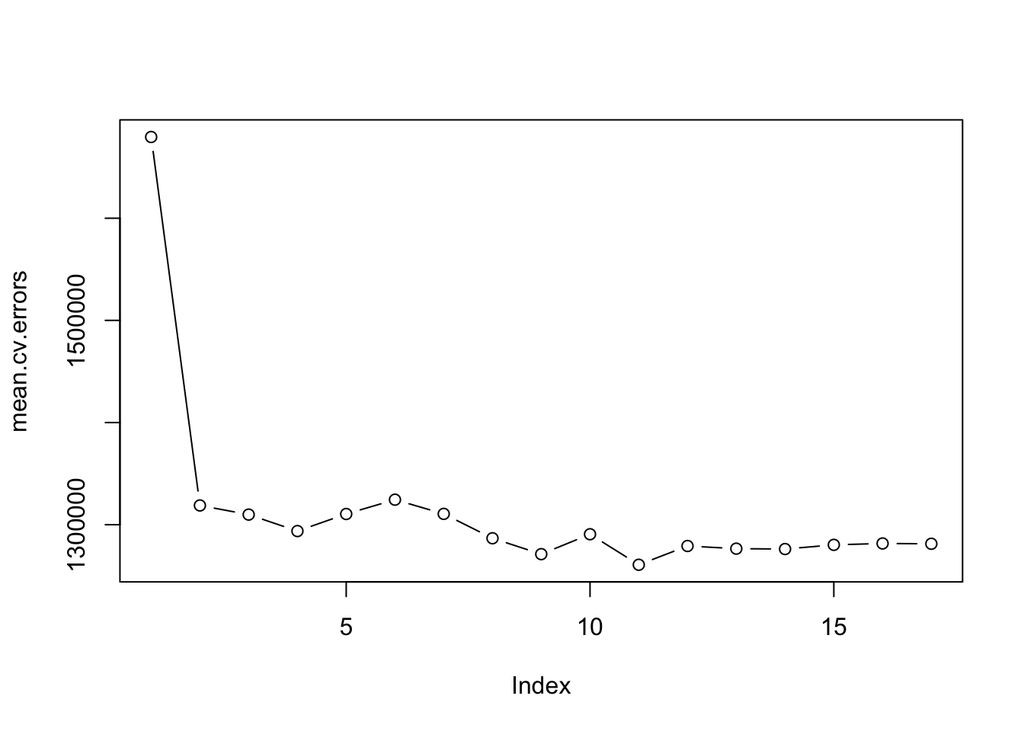

```r
par(mfrow = c(1, 1))
plot(mean.cv.errors, type = "b")
```

```r
# 10 Variable model

reg.best <- regsubsets(Apps ~ ., data = College,nvmax = 17)
coef(reg.best, 10)
```

```
##   (Intercept)    PrivateYes        Accept        Enroll     Top10perc
## -100.51668243 -575.07060789    1.58421887   -0.56220848   49.13908916
##     Top25perc      Outstate    Room.Board           PhD        Expend
##  -13.86531103   -0.09466457    0.16373674  -10.01608705    0.07273776
##     Grad.Rate
##    7.33268904
```

### c) Ridge Regression

#### Fit a ridge regression model on the training set, with λ chosen by cross-validation. Report the test error obtained.

```r
x <- model.matrix(Apps ~ ., College)[, -1]
y <- College$Apps

set.seed(777)
train <- sample(1:nrow(x), nrow(x) / 2)
test <- (-train)
y.test <- y[test]

grid <- 10^seq(10, -2, length = 100)
ridge.mod <- glmnet(x, y, alpha = 0, lambda = grid)

dim(coef(ridge.mod))
```

```
## [1]  18 100
```

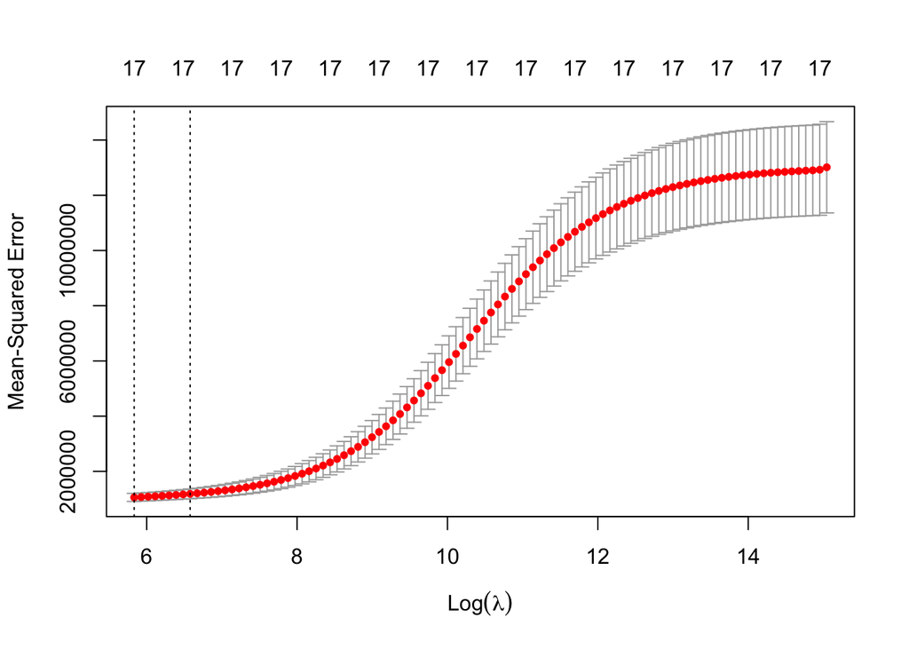

```r
cv.out <- cv.glmnet(x[train, ], y[train], alpha = 0)
plot(cv.out)
```

```r
bestlam <- cv.out$lambda.min
bestlam
```

```
## [1] 341.6319
```

```r
ridge.pred <- predict(ridge.mod, s = bestlam, newx = x[test, ])
mean((ridge.pred - y.test)^2)
```

```
## [1] 1823376
```

```r
options(scipen=999)
out <- glmnet(x, y, alpha = 0)
predict(out, type = "coefficients", s = bestlam)[1:18, ]
```

```
##    (Intercept)     PrivateYes         Accept         Enroll      Top10perc
## -1468.32567670  -527.87807813     1.00458822     0.43134421    25.80618727
##      Top25perc    F.Undergrad    P.Undergrad       Outstate     Room.Board
##     0.55010920     0.07258520     0.02420595    -0.02407454     0.19877316
##          Books       Personal            PhD       Terminal      S.F.Ratio
##     0.12854768    -0.00814613    -4.02828399    -4.81107125    13.02180031
##    perc.alumni         Expend      Grad.Rate
##    -8.54478314     0.07589013    11.26699271
```

Value of λ that results in the smallest cross validation error is 341.6

Test MSE of this is 1823376

### d) Lasso Model

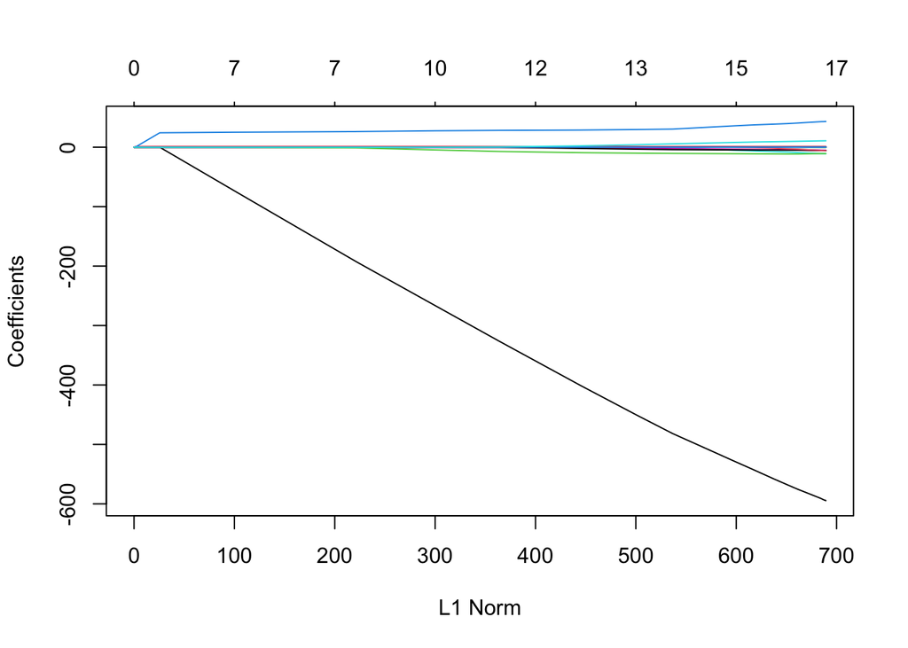

```r
set.seed(777)
train <- sample(1:nrow(x), nrow(x) / 2)
test <- (-train)
y.test <- y[test]

lasso.mod <- glmnet(x[train, ], y[train], alpha = 1, lambda = grid)
plot(lasso.mod)
```

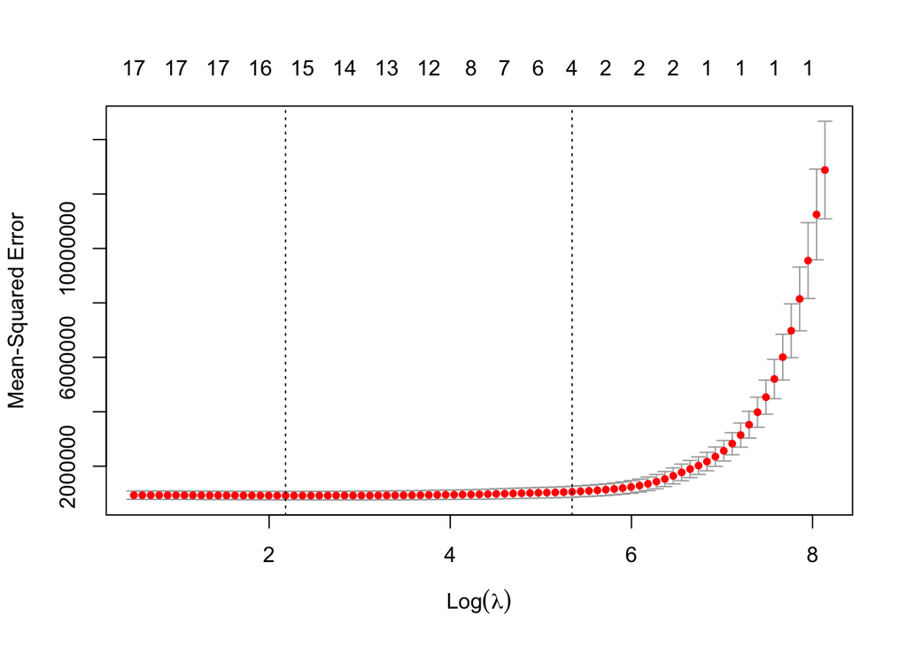

```r
set.seed(777)

cv.out <- cv.glmnet(x[train, ], y[train], alpha = 1)
plot(cv.out)
```

```r
bestlam <- cv.out$lambda.min
lasso.pred <- predict(lasso.mod, s = bestlam,
newx = x[test, ])

mean((lasso.pred - y.test)^2)
```

```
## [1] 1555348
```

```r
out <- glmnet(x, y, alpha = 1, lambda = grid)
lasso.coef <- predict(out, type = "coefficients", s = bestlam)[1:18, ]
lasso.coef
```

```
##    (Intercept)     PrivateYes         Accept         Enroll      Top10perc
## -523.330787978 -481.283713661    1.531039335   -0.452248739   43.114818711
##      Top25perc    F.Undergrad    P.Undergrad       Outstate     Room.Board
##   -8.985104939    0.001889549    0.042254550   -0.075580106    0.142330346
##          Books       Personal            PhD       Terminal      S.F.Ratio
##    0.000000000    0.021910616   -7.540028679   -3.031947899   11.549852951
##    perc.alumni         Expend      Grad.Rate
##   -0.506765926    0.074457081    7.109294830
```

MSE is 1555348. This is a slightly lower but similar test score to the test MSE of the ridge regression model with λ chosen by cross validation.

However, with the lasso model we see that 1 of the 17 coefficient estimates are exactly zero. So, the lasso model with λ chosen by cross-validation contains only sixteen variables.